# Lab 21: Sixteen Personality Factors I

## Instructions

Below you will find several empty R code scripts and answer prompts. Your task is to fill in the required code snippets and answer the corresponding questions.

## Sixteen Personality Factors: Pick Your Trait

Over the next two classes we are going to be looking at survey response data from the Sixteen Personality Factor Questionnaire in order to practice our skills at statistical inference:

The dataset use the following fields:

- age: respondent’s age in years
- gender: respondent’s self-selected gender
- country: two letter IATA code for the respondent’s IP
- elapsed: time taken to complete quiz in seconds
- warmth: personality score from 1-20
- reasoning: personality score from 1-20
- emotional_stability: personality score from 1-20
- dominance: personality score from 1-20
- liveliness: personality score from 1-20
- rule_consciousness: personality score from 1-20
- social_boldness: personality score from 1-20
- sensitivity: personality score from 1-20
- vigilance: personality score from 1-20
- abstractedness: personality score from 1-20
- privateness: personality score from 1-20
- apprehension: personality score from 1-20
- openness_to_change: personality score from 1-20
- self_reliance: personality score from 1-20
- perfectionism: personality score from 1-20
- tension: personality score from 1-20
- baseline: average score across all 16 personality traits

*To start with, select a particular trait that you will use for the first bank of questions. I suggest picking something that popped out when you took the test. You can pick any of the 16 other than sensitivity.*

Produce a bar plot of the personality scores for your trait.

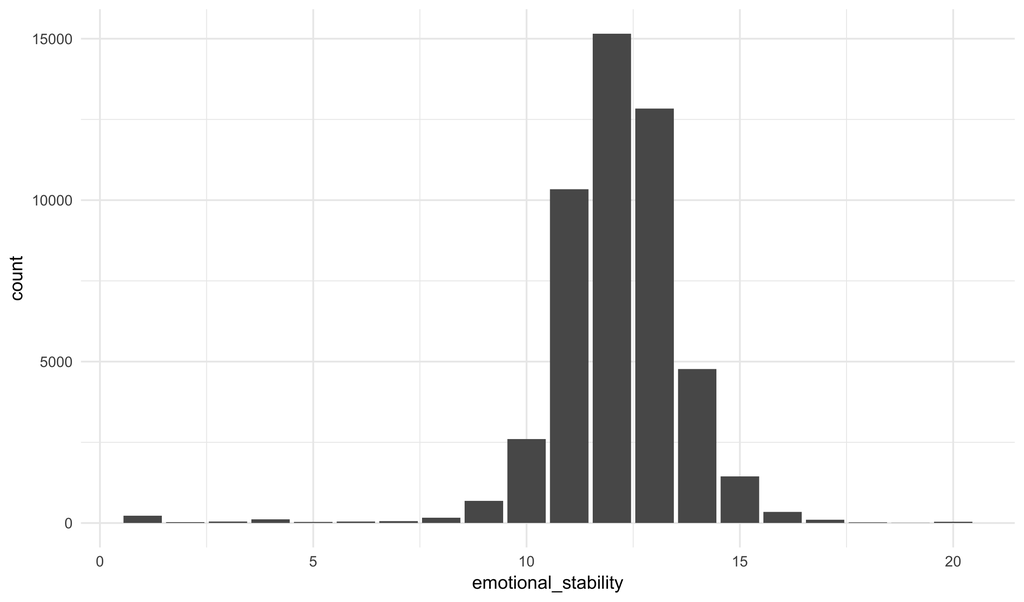

Describe the distribution. Why does a bar plot work here even though the variable is numeric?

**Answer**: The majority of people scored an 11, 12, or 13 out of 20. A bar plot works because the scores fall on intervals from 0-20 like categories.

Produce a confidence interval for the mean of your trait.

```
##
## Call:
## lm_basic(formula = emotional_stability ~ 1, data = pf)
##
## Residuals:
##      Min       1Q   Median       3Q      Max
## -11.1205  -1.1205  -0.1205   0.8795   7.8795
##
## Coefficients:
##             Estimate 2.5 % 97.5 %
## (Intercept)    12.12 12.11  12.13
##
## Residual standard error: 1.636 on 49059 degrees of freedom
```

Now, produce a dataset that consists only of responses from the country of Hungary. The 2-letter country code for Hungary is “HU”. Produce a confidence interval for your trait on the Hungarian dataset.

```
##
## Call:
## lm_basic(formula = emotional_stability ~ 1, data = pf_hungary)
##
## Residuals:
##     Min      1Q  Median      3Q     Max
## -4.2364 -1.2364 -0.2364  0.7636  2.7636
##
## Coefficients:
##             Estimate 2.5 % 97.5 %
## (Intercept)    12.24 11.89  12.59
##
## Residual standard error: 1.29 on 54 degrees of freedom
```

What do you notice about this confidence interval compared to the original one? Can you explain why this is the case?

**Answer**: The confidence interval has a larger range for Hungary than for the whole unfiltered dataset. This may be because there are fewer responses for the smaller dataset and so the data is less generalized.

Find a 95% confidence interval for the difference between the average male and female value for your personality trait on the Hungarian data.

```
##
## Call:
## lm_basic(formula = emotional_stability ~ 1 + gender, data = pf_hungary)
##
## Residuals:
##     Min      1Q  Median      3Q     Max
## -4.1739 -1.1739 -0.1739  0.8261  2.7187
##
## Coefficients:
##             Estimate   2.5 % 97.5 %
## (Intercept)  12.2813 11.8198 12.743
## gendermale   -0.1073 -0.8209  0.606
##
## Residual standard error: 1.301 on 53 degrees of freedom
## Multiple R-squared:  0.001714,   Adjusted R-squared:  -0.01712
## F-statistic: 0.09102 on 1 and 53 DF,  p-value: 0.7641
```

**Answer**: -0.1073

Is there a statistically significant difference between men and women’s average score? If so, what direction is this difference? Does this challenge or confirm traditional gender stereotypes (note: not all personality traits have one)?

**Answer**: There is no statistically significant difference between men and women’s average score because the confidence interval includes a positive and negative number. This implies that men and women have similar scores, not necessarily conforming to gender stereotypes, but slightly challenging them.

Construct a new dataset that only has ages from 30-49 (from the original `pf`, not just the Hungarian subset). Hint: you can use the filter function twice.

On the dataset of people ages 30 to 49, create a variable called `fourties` if age is greater than or equal to 40.

Fit a regression on with your personality trait as a response to test for the difference between its mean for people in their 30s versus people in their 40s. Compute a confidence interval for this difference.

```
##
## Call:
## lm_basic(formula = emotional_stability ~ 1 + forties, data = age30_49)
##
## Residuals:
##      Min       1Q   Median       3Q      Max
## -10.8612  -0.8524   0.1388   1.1388   8.1388
##
## Coefficients:
##              Estimate     2.5 % 97.5 %
## (Intercept) 11.861226 11.818993  11.90
## fortiesTRUE -0.008803 -0.077767   0.06
##
## Residual standard error: 1.676 on 9683 degrees of freedom
## Multiple R-squared:  6.465e-06,  Adjusted R-squared:  -9.681e-05
## F-statistic: 0.06261 on 1 and 9683 DF,  p-value: 0.8024
```

Is there a statistically significant difference between 30s and 40s average scores? If so, what direction is this difference? Does this challenge or confirm traditional age stereotypes (note: not all personality traits have one)?

**Answer**: There is no statistically significant difference, and neither challenges nor confirms traditional age stereotypes.

Draw a bar plot of the variable `country` over the whole dataset. Take note of the number of countries with a very small number of responses.

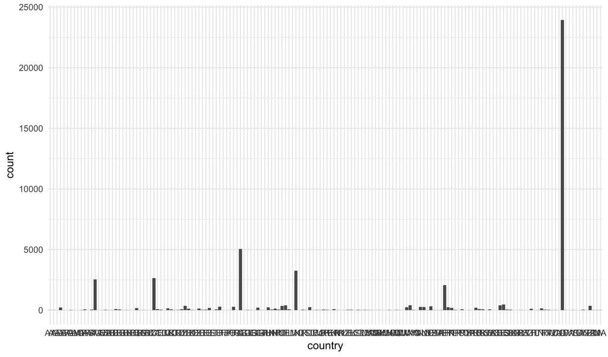

Fitting a model with all of these countries is possible but not very useful. When we only have a few responses from some places it makes those few regions with a lot of data harding to identify and analyze. Fortunately there is a solution in the function `fct_lump`.

Fit a regression model on the entire dataset by the country variable lumped into 5 categories.

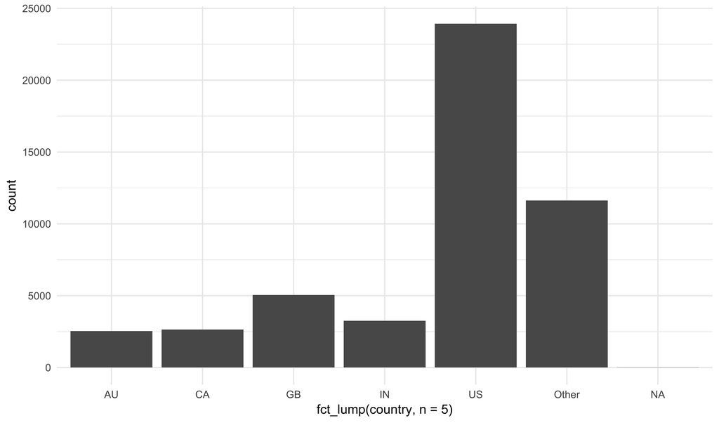

Using the previous model, which country (not including “Other”) has the highest score for your trait? Which has the lowest?

```
##
## Call:
## lm_basic(formula = emotional_stability ~ fct_lump(country, 5),
##     data = pf)
##
## Residuals:
##      Min       1Q   Median       3Q      Max
## -11.2568  -1.0592  -0.0592   0.9408   7.9408
##
## Coefficients:
##                             Estimate      2.5 % 97.5 %
## (Intercept)               12.1310699 12.0674145 12.195
## fct_lump(country, 5)CA     0.0006984 -0.0883988  0.090
## fct_lump(country, 5)GB    -0.0619746 -0.1399748  0.016
## fct_lump(country, 5)IN     0.1257742  0.0408677  0.211
## fct_lump(country, 5)US    -0.0719171 -0.1388556 -0.005
## fct_lump(country, 5)Other  0.0955188  0.0252721  0.166
##
## Residual standard error: 1.635 on 49037 degrees of freedom
##   (17 observations deleted due to missingness)
## Multiple R-squared:  0.002249,   Adjusted R-squared:  0.002148
## F-statistic: 22.11 on 5 and 49037 DF,  p-value: < 2.2e-16
```

## Fitting Sensitivity Scores

Fit a model that predicts sensitivity as a function of the baseline score.

```
##
## Call:
## lm_basic(formula = sensitivity ~ 1 + baseline, data = pf)
##
## Residuals:
##     Min      1Q  Median      3Q     Max
## -7.3533 -0.8905  0.0477  0.9890  6.4613
##
## Coefficients:
##             Estimate   2.5 % 97.5 %
## (Intercept)  0.16645 0.03733  0.296
## baseline     0.93818 0.92830  0.948
##
## Residual standard error: 1.483 on 49058 degrees of freedom
## Multiple R-squared:  0.4139, Adjusted R-squared:  0.4139
## F-statistic: 3.465e+04 on 1 and 49058 DF,  p-value: < 2.2e-16
```

Is the slope statistically significantly different from 1? Why is this an interesting question in the context of the data?

**Answer**: Yes, as sensitivity score increases, so does baseline score.

Fit a regression model that uses both gender and the baseline score to predict your trait.

```
##
## Call:
## lm_basic(formula = sensitivity ~ 1 + baseline + gender, data = pf)
##
## Residuals:
##     Min      1Q  Median      3Q     Max
## -7.4486 -0.8698  0.0270  0.9565  6.3742
##
## Coefficients:
##             Estimate   2.5 % 97.5 %
## (Intercept)   0.5419  0.4136  0.670
## baseline      0.9260  0.9163  0.936
## gendermale   -0.5495 -0.5760 -0.523
##
## Residual standard error: 1.459 on 49057 degrees of freedom
## Multiple R-squared:  0.4331, Adjusted R-squared:  0.4331
## F-statistic: 1.874e+04 on 2 and 49057 DF,  p-value: < 2.2e-16
```

Describe the slope for the gender term in words:

**Answer**: Males tend to have significantly lower sensitivity scores than females.

Add predictions from the previous model to `pf`.

Plot the baseline score as a function of `model_pred`, coloring the points base on the gender variable.

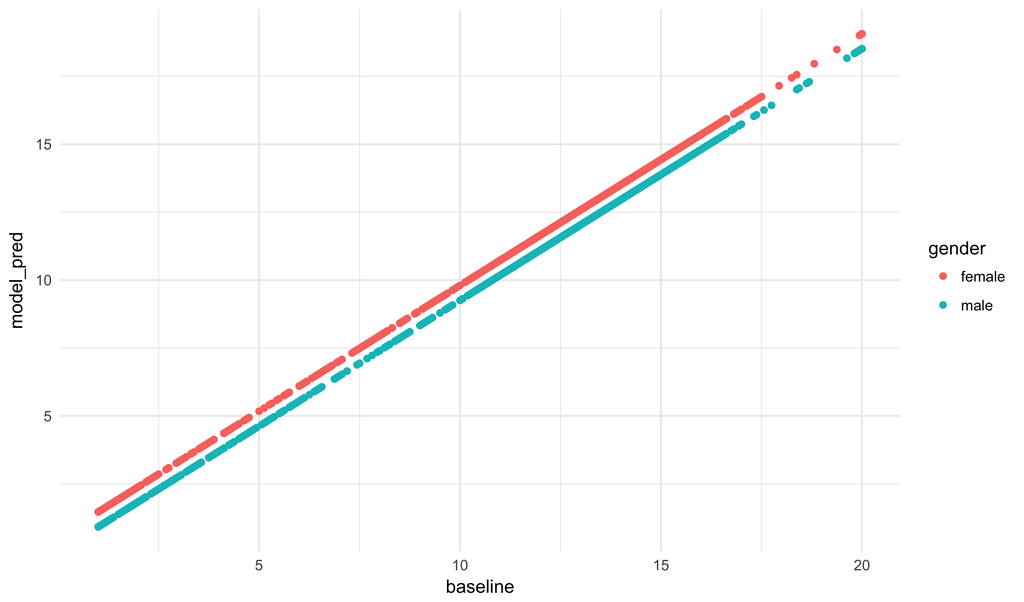

What do the predicted values look like?